# Guide for 16S rRNA gene-based microbial diversity analysis

Belén Carbonetto @UBI-IGC

March 5, 2018

## UBI’s protocol

You will find in this document a **guide** to microbial diversity analysis as we perform in the UBI.

*Note:* This is not a tutorial, but if you want to follow the steps you can download this small example dataset and try every step by yourself. This dataset was obtained by transforming data originally from [Batista et al. (2015)](https://www.nature.com/articles/ncomms9945#Fig5). It consists of data corresponding to mice gut microbiota under 2 conditions (WT untreated and WT after Streptomycin treatment) with 4 replicates each, where exactly 10000 reads were obtained from the original forward raw reads of each sample. This dataset includes also a mapping file and a parameter file.

Reference databases are not provided as they will be available in the QIIME environment after [instalation](http://qiime.org/install/install.html).

If not available in your QIIME version, last GreenGenes database version can be downloaded from here

### In the Lab: 16S primers and sequencing

The first step for a microbial community analysis based on the 16S rRNA gene is the selection of the amplification region. This will depend, among several [other criteria](https://www.ncbi.nlm.nih.gov/pmc/articles/PMC3592464/), on the sequencing technology to be used. We use Illumina MiSeq technology so we need to choose a region of no more than [300 bp](https://www.illumina.com/systems/sequencing-platforms.html) which is the maximum sequencing length. The IGC sequencing facility has chosen the V4 region and the [515f/806r](http://msystems.asm.org/content/1/1/e00009-15) primers. [Here](http://press.igsb.anl.gov/earthmicrobiome/protocols-and-standards/16s/) is the protocol followed by the IGC sequencing facility for library preparation and sequencing with the MiSeq platform.

### We have the sequences, what do we do now?

Once the sequencing facility delivers the raw reads, we can start with the *processing* and *analysis*.

**Analysis involve next steps:**

1. Pre-processing of sequences: remove primers and barcodes, demultiplex samples, quality filtering and chimera removal.
2. Pick features and representative sequences.
3. Assign taxonomy to reads or features.
4. Align sequences and infer phylogeny.
5. Calculate alpha and beta diversity.
6. Test for differential abundances between groups of samples.
7. Visualization.

[figure not shown]

### **Removal of primers and barcodes: Custom script**

In the UBI we use a custom script to remove barcodes and primer sequences. This script also demultiplex reads by sample, according to barcode (i.e. unique identifier) information. Actually, this step is performed by the sequencing facility that later delivers demultiplexed **.fastq** files. Then, our input material for the analysis is a collection of *.fastq* files, one for each sample sent for sequencing by the user.

The nomenclature used by the sequencing facility today is:

**sample_name_by_user_L001_R1_001.fastq** for forward reads

**sample_name_by_user_L001_R1_001.fastq** for reverse reads

### **QIIME metadata file**

We are using tools implemented in [QIIME](http://qiime.org/) for most of the processing and analysis steps.

We should change the names of the fastq files (and subsequently sequence IDs) to eliminate underscores “_" because QIIME can only deal with alphanumeric characters and “.” for sample IDs.

We can use the following command:

```bash
rename -v  's/_/./g' *.fastq
```

QIIME needs us to provide a [metadata file](http://qiime.org/documentation/file_formats.html) for some processing steps. This file contains all the information about the samples necessary to perform the data analysis. In general, the mapping file should contain the name of each sample and a description column. One should also include any metadata that relates to the samples (for instance, health status or sampling site).

Before using the mapping file in any step we check it is correct by using the following command on the [QIIME environment](http://qiime.org/install/install.html)::

```bash
validate_mapping_file.py -m mapping_file.txt -o verified_mapping_file
```

### **Quality filtering- QIIME: *multiple_split_libraries_fastq.py***

In order to analyze data using QIIME we need to put all reads in one single [FASTA](https://en.wikipedia.org/wiki/FASTA_format) file. We do this using the *multiple_split_libraries_fastq.py* command. This command will also perform quality trimming and filtering of reads.

All the files we want to use should be in the same folder, in this case we run the analysis only on forward reads so we named the folder **R1**. Then, we run the next line:

```bash
mkdir split_libraries
multiple_split_libraries_fastq.py -i fastq/R1 -o split_libraries --demultiplexing_method sampleid_by_file --sampleid_indicator .L001.R1.001 -p param_file.txt
```

This command will work on the input directory *fastq/R1* containing the fastq files, where each file is named on a per-sample basis. (i.e. sample ids are in the fastq file names). In this case the text before **.L001.R1.001** will be printed as sample id in the output fasta file. Quality filtering is also performed in this step. A [*parameter file*](http://qiime.org/documentation/qiime_parameters_files.html) is passed with the parameters needed for quality filtering.

We are using a quality minimum limit of Q20 so we are passing:

**–phred_quality_threshold 19**

The rest of the quality trimming parameters are used as default:

**–min_per_read_length_fraction 0.75** (i.e. 75% of total read length is the minimum size of consecutive high-quality bases for a read to be retained)

**–sequence_max_n 0** (i.e. we don’t allow ambiguous “N” characters)

**–max_bad_run_length 3** (i.e. three is the maximum number of consecutive low-quality (< Q20) bases allowed before truncating a read)

### **Chimera removal_ QIIME: *identify_chimeric_seqs.py***

We use the following steps in order to eliminate [chimeras](https://www.drive5.com/usearch/manual/chimera_formation.html) produced during the library preparation process:

Step 1: Chimera detection

```bash
identify_chimeric_seqs.py -i split_libraries/seqs.fna -m usearch61 -o usearch_checked_chimeras/ -r ~/miniconda3/envs/qiime1/lib/python2.7/site-packages/qiime_default_reference/gg_13_8_otus/rep_set/97_otus.fasta
```

Step 2: filtering of chimeric reads

```bash
filter_fasta.py -f split_libraries/seqs.fna -o usearch_checked_chimeras/seqs_chimeras_filtered.fna -s usearch_checked_chimeras/chimeras.txt -n
```

**usearch61** performs abundance based and reference based detection of chimeras. Click [here](http://drive5.com/usearch/usearch_docs.html) for details on the method.

It is useful to count the number of sequences before and after filtering chimeras:

```bash
grep -c '>' split_libraries/seqs.fna
grep -c '>' usearch_checked_chimeras/seqs_chimeras_filtered.fna
```

### **Pick OTUs and taxonomic classsification-QIIME: *pick_open_reference_otus.py***

OTU clusterization is done using a combination of closed reference and *de novo* algorithms. This is implemented using *uclust*. You can read more about this method [here](https://peerj.com/articles/545.pdf).

```bash
pick_open_reference_otus.py -i usearch_checked_chimeras/seqs_chimeras_filtered.fna -r ~/miniconda3/envs/qiime1/lib/python2.7/site-packages/qiime_default_reference/gg_13_8_otus/rep_set/97_otus.fasta -o chimera_filtered_open_ref_otus/
```

The primary output is the *OTU table* which is a .biom file that can be turned into a tab separated table using the following command:

```bash
biom convert -i chimera_filtered_open_ref_otus/otu_table_mc2_w_tax_no_pynast_failures.biom -o chimera_filtered_open_ref_otus/otu_table_mc2_w_tax_no_pynast_failures.txt --to-tsv --header-key taxonomy
```

This command also assigns a taxonomic string to each OTU. OTUs derived from the reference keep their original classification in the database. For *de novo* OTUs, each representative sequence is classified using a uclust-based classifier at 90% similarity level against the same data base.

The OTU table is filtered, OTUs with less than 2 reads are removed, as well as OTUs whose representative (i.e., centroid) sequence can’t be aligned with PyNAST. PyNASt alignment is used to produce a phylogenetic tree where the tips are the OTUs. The output file containing the tree is **rep_set.tre**, and is used with **otu_table_mc2_w_tax_no_pynast_failures.biom** in downstream phylogenetic diversity calculations (i.e.Unifrac).

Since OTUs already have an assigned taxonomic string, we can collapse the taxa information in tables for different taxonomic levels, from L2= Phylum to L6= Genus.

```bash
summarize_taxa.py -i chimera_filtered_open_ref_otus/otu_table_mc2_w_tax_no_pynast_failures.biom -o chimera_filtered_open_ref_otus/tax_rel/
summarize_taxa.py -i chimera_filtered_open_ref_otus/otu_table_mc2_w_tax_no_pynast_failures.biom -o chimera_filtered_open_ref_otus/tax_abs/ -a
```

We use the parameter **-a** to get tables with the absolute counts for each taxa category. If **-a** is not passed, the tables contain taxa relative abundances.

In order to compute some summary statistics on the OTU table we run the following command:

```bash
biom summarize-table -i chimera_filtered_open_ref_otus/otu_table_mc2_w_tax_no_pynast_failures.biom
```

The key piece of information we get from the output is the depth of sequencing that should be used in subsequent diversity analyses

A way to deal with the unevenness of sample sizes is to use rarefaction (i.e. subsampling without replacement) to an equal number of sequences in each sample. So, we need to review the **Counts/sample** detail and decide what depth we will use for sub sampling. Any samples that don’t have at least that many sequences will not be included in the analyses, so this decision is always a trade-off between the number of sequences you throw away and the number of samples you throw away.

### **Diversity analysis- QIIME: *core_diversity_analyses.py***

If you downloaded the example dataset, you will notice that the less abundant sample has 7717 reads. Then, we run the following:

```bash
core_diversity_analyses.py -i chimera_filtered_open_ref_otus/otu_table_mc2_w_tax_no_pynast_failures.biom -o chimera_filtered_open_ref_otus/core_output -m mapping_file.txt -t chimera_filtered_open_ref_otus/rep_set.tre -e 7717 -c AntibioticUsage  -p param_file.txt
```

**-e** defines the size for subsampling

**-c** defines what metadata column included in the mapping file will be used to create the interactive plots and color bar and area charts. In this we use “AntibioticUsage”"

**-p** we pass the parameter file in order to calculate more diveristy metrics:

**beta_diversity:metrics bray_curtis,unweighted_unifrac,weighted_unifrac**

**alpha_diversity:metrics shannon,chao1,observed_otus**

This command calculates the diversity metrics listed above and produces interactive Principal Coordinate Analysis plots based on the distance matrices for each beta diveristy metric.

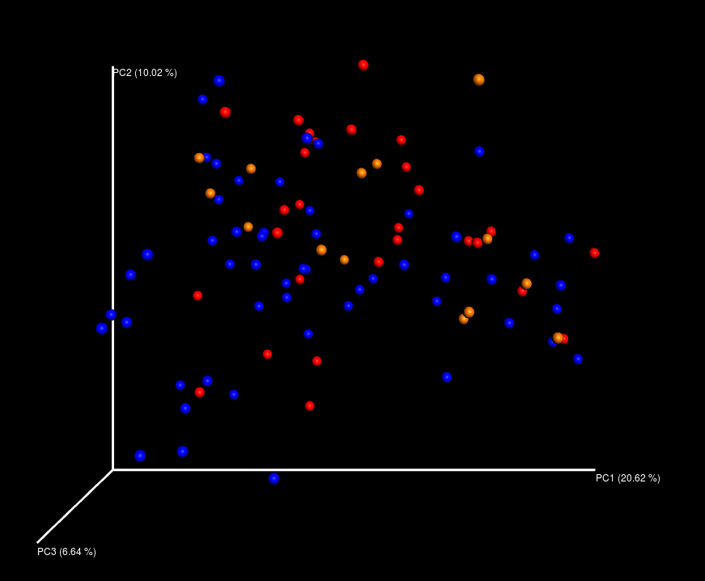

Or as for the example dataset:

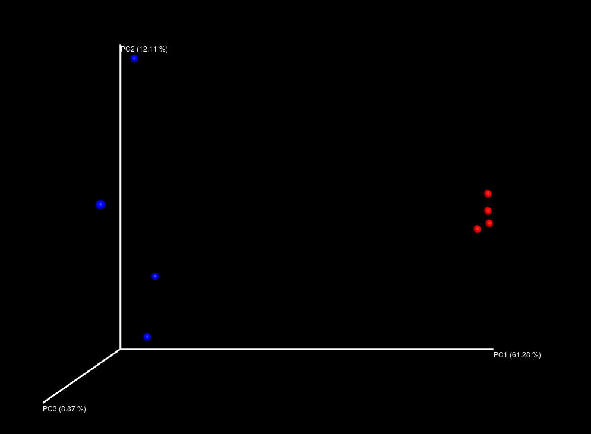

It also generates area and bar charts to visually compare relative abundances of taxa.

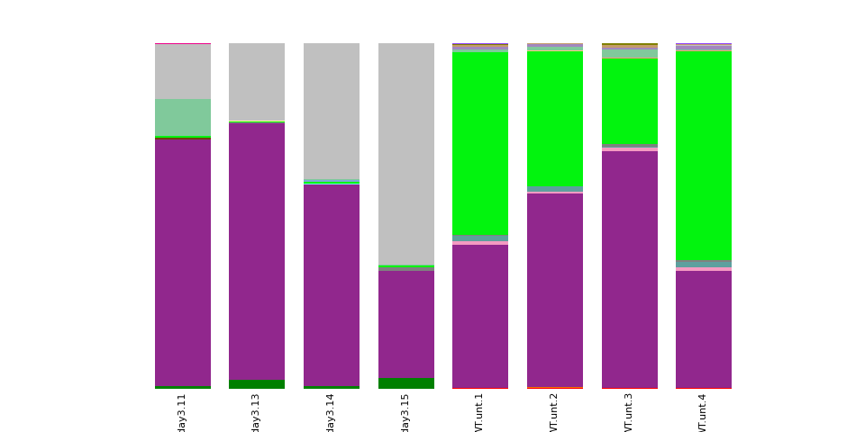

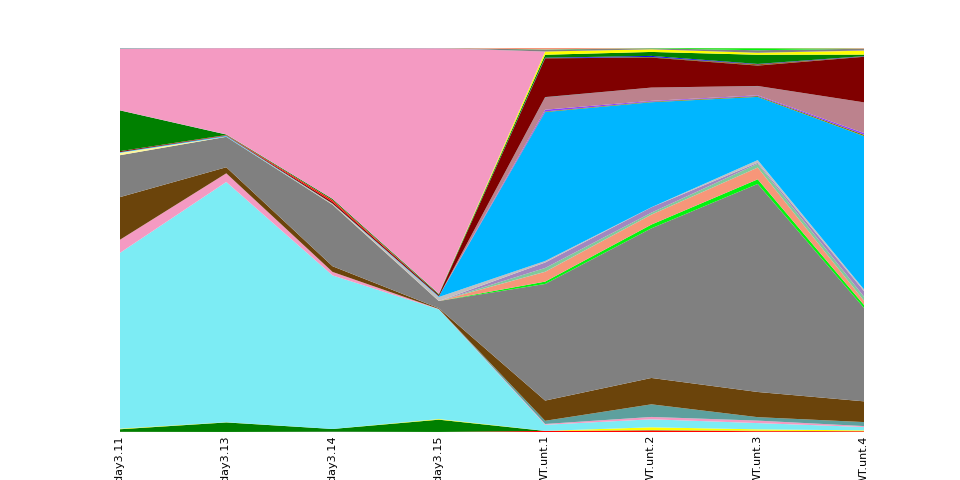

Moreover, because we pass the **-c** parameter, it calculates statistics tests to compare alpha and beta diversity measures between the levels of factors provided. It uses a non-parametric t-test based on Monte Carlo permutations to compare alpha diversity values and Kruskall Wallis test to compare taxonomic abundances on rarefied taxa.

We also unzip and transform into a .txt file the rarefied OTU table:

```bash
gunzip table_even7717.biom.gz
biom convert -i chimera_filtered_open_ref_otus/core_output/table_even7717.biom -o chimera_filtered_open_ref_otus/core_output/table_even7717.txt --to-tsv --header-key taxonomy
```

### **Extra comparisons- QIIME:**

We also run Kruskall Wallis on taxonomy tables with relative abundances:

```bash
group_significance.py -i chimera_filtered_open_ref_otus/core_output/taxa_plots/table_mc7717_sorted_L6.biom -m mapping_file.txt -c AntibioticUsage -s kruskal_wallis -o chimera_filtered_open_ref_otus/core_output/taxa_plots/L6_KW.txt --permutations 999
```

This last line is ran for every taxonomic table from L2 to L6.

### Beyond QIIME:

Even if QIIME allows a very efficient and convenient tool for sequence processing and the calculation of diversity metrics we use **R** to run more comparisons and for the visualization of results.

### **Boxplot for differential abundances**

```r
#Load needed libraries (install first using install.packages())
library("qiimer")
library('ggplot2')
#
#Import tables to make a boxplot with the abundances of taxa with significant differential abudance between metadata levels.
#We first need to  import the table with taxa abundances and the mapping file with factors that describe the samples
#Mapping file:
mapping_file<-read.delim2("mapping_file.txt", row.names=1)
#
#Taxa table at Genus level (L6) with relative abundances
comp_L6<-read.delim2("chimera_filtered_open_ref_otus/tax_rel/otu_table_mc2_w_tax_no_pynast_failures_L6.txt", row.names = 1, sep = "\t", skip =1, dec = ".", header= TRUE)
#
#We also import the results of the Kruskall Wallis test:
#
L6_sig<-read.table("chimera_filtered_open_ref_otus/core_output/taxa_plots/L6_KW.txt", header=TRUE, sep="\t", row.names = 1)
#
#We need to format the data frames in order to use them as input for comparison analisys and plotting
#
comp_L6<-t(comp_L6)
comp_L6<-as.data.frame(comp_L6)
#
#We need order the rows in comp_L6 accoring to the order in mapping by rownames-Factors for comparison tests are taken from the mapping_file. Sample names must be in the same order in all objects
#
comp_L6<-comp_L6[match(rownames(mapping_file), rownames(comp_L6)),]
#
#We capture only get the names of the rows which have a value <= 0.05 in column FDR_P
#
L6_sig_names<-rownames(L6_sig[L6_sig$FDR_P<=0.05,])
#get only the significant categories from L6 tax table and make a new table
#
comp_L6_sig<-subset(comp_L6, select = L6_sig_names)
#Split taxa names in columns
#
comp_L6_sig_names_split<-split_assignments(colnames(comp_L6_sig),split = ";")
#
# delete "_" and "g", "f", etc, from names
comp_L6_sig_names_split$Kingdom<-gsub("k__", "", comp_L6_sig_names_split$Kingdom, fixed= TRUE)
comp_L6_sig_names_split$Phylum<-gsub("p__", "", comp_L6_sig_names_split$Phylum, fixed= TRUE)
comp_L6_sig_names_split$Class<-gsub("c__", "", comp_L6_sig_names_split$Class, fixed= TRUE)
comp_L6_sig_names_split$Order<-gsub("o__", "", comp_L6_sig_names_split$Order, fixed= TRUE)
comp_L6_sig_names_split$Family<-gsub("f__", "", comp_L6_sig_names_split$Family, fixed= TRUE)
comp_L6_sig_names_split$Genus<-gsub("g__", "", comp_L6_sig_names_split$Genus, fixed= TRUE)
#
#Make a new table with splitted names
#
comp_L6_sig_t<-t(comp_L6_sig)
comp_L6_sig_t<-as.data.frame(comp_L6_sig_t)
comp_L6_sig_t_split<-cbind(comp_L6_sig_names_split,comp_L6_sig_t)
#
#Define which factor for metadata we want to use for plotting
#
factor<-mapping_file$AntibioticUsage
#
#Plot only taxa with significant DA and save plots in a pdf file
#
pdf(file="L6_boxplots.pdf")
for (index in 1:dim(comp_L6_sig_t_split)[[1]]){
  W<-data.frame(values=unlist(comp_L6_sig_t_split[index,7:dim(comp_L6_sig_t_split)[[2]]]),metadata=factor)
  plot<-(ggplot(data= W, aes(x=W$metadata, y=W$values, fill=W$metadata)))+
  geom_boxplot(notch = FALSE, show.legend = FALSE)+
  geom_point(show.legend = FALSE)+
  theme_bw()+
  labs(y="Relative Abundance", x="Treatment")+
  ggtitle(paste(comp_L6_sig_t_split$Order[index],comp_L6_sig_t_split$Family[index],comp_L6_sig_t_split$Genus[index], sep=" "))+
    stat_summary(fun.y=mean, colour="gray34", geom="point",shape=18, size=4, show.legend = FALSE)
  print(plot)
}
dev.off()
```

Here is an example of the boxplots produced:

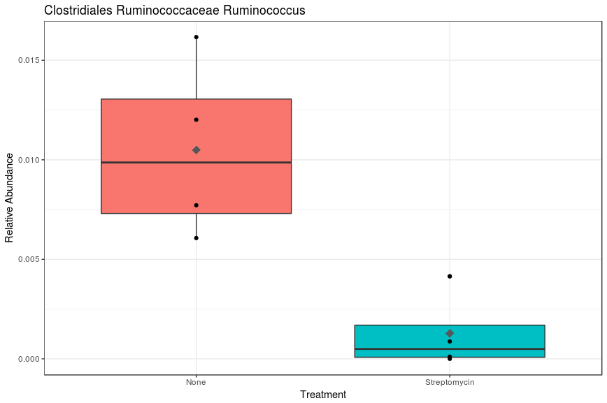

### **Customized PCoA plots**

Even if the output from QIIME *core_diversity_analyses.py* has intereactive PCoA plots which are useful for a first exploration of results they have not *figure quality* and cannot be customized.

We can then plot custom PCoAs in R:

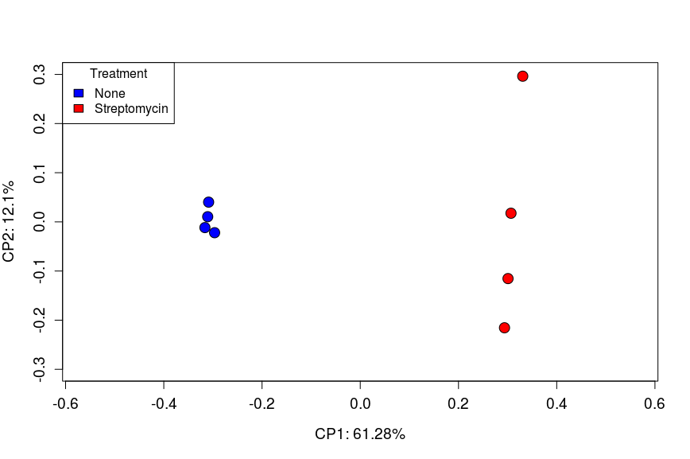

```r
##Load needed libraries (install first using install.packages())
#
library("BiodiversityR")
#
#Import tables: mapping file, rarefied OTU table and distance matrix
#
mapping_file<-read.delim2("mapping_file.txt", row.names=1)
OTU_table<-read.delim2("chimera_filtered_open_ref_otus/core_output/table_even7717.txt",row.names = 1, sep = "\t", skip =1, dec = ".", comment.char = "")
unweighted_unifrac_dm<-read.delim2("chimera_filtered_open_ref_otus/core_output/bdiv_even7717/unweighted_unifrac_dm.txt", row.names = 1, sep = "\t", dec = ".")
#
#We need to format the data frames in order to use them as input for comparison analisys and plotting
#We need to re-order the rows in the tables and matrix so as sample names are in the same order in all objects
#
OTU_table<-OTU_table[,1:dim(OTU_table)[2]-1]
OTU_table<-t(OTU_table)
OTU_table<-as.data.frame(OTU_table)
OTU_table<-OTU_table[match(rownames(mapping_file), rownames(OTU_table)),]
unweighted_unifrac_dm<-unweighted_unifrac_dm[match(rownames(mapping_file), rownames(unweighted_unifrac_dm)),]
unweighted_unifrac_dm<-t(unweighted_unifrac_dm)
unweighted_unifrac_dm<-as.data.frame(unweighted_unifrac_dm)
unweighted_unifrac_dm<-unweighted_unifrac_dm[match(rownames(mapping_file), rownames(unweighted_unifrac_dm)),]
unweighted_unifrac_dm_dist<-as.dist(unweighted_unifrac_dm)
#
#Calculate PCoA
unweighted_unifrac_dm_dist_pcoa<-cmdscale(unweighted_unifrac_dm_dist,k=nrow(OTU_table)-1,eig=T,add=F)
unweighted_unifrac_dm_dist_pcoa_2<-add.spec.scores(unweighted_unifrac_dm_dist_pcoa, OTU_table, method="pcoa.scores",Rscale=T, scaling=1,multi=1)
#
#Draw PCoA- Colored by selected metadata factor
#
color_palete<-c("blue"," red")
groups<-levels(mapping_file$AntibioticUsage)
pdf(file="unweighted_unifrac_PCoA.pdf")
plot_unweighted_unifrac_dm_dist_pcoa<-ordiplot(unweighted_unifrac_dm_dist_pcoa_2,type="points", display="sites",ann=FALSE, cex.axis=1.2, ylim =c(-0.3, 0.3), xlim =c(-0.2, 0.2))
mapply(function(group,color){
  points(plot_unweighted_unifrac_dm_dist_pcoa,"sites",cex = 1.8, pch=21, col="black", bg=color, select=rownames(mapping_file[mapping_file$AntibioticUsage==group,]))
}, groups, color_palete)
legend(x="topleft",legend=groups, fill= color_palete, title="Treatment", cex= 1)
ordiellipse(unweighted_unifrac_dm_dist_pcoa_2, mapping_file$AntibioticUsage, draw = c("lines"), kind= c("sd"), conf=0.95, lty = 2)
XLAB<-paste(c("CP1: ", format(unweighted_unifrac_dm_dist_pcoa_2$eig.percen[1],digits = 4, format= "f"), "%"), collapse = "")
XLAB<-noquote(XLAB)
YLAB<-paste(c("CP2: ", format(unweighted_unifrac_dm_dist_pcoa_2$eig.percen[2],digits = 3, format= "f"), "%"), collapse = "")
YLAB<-noquote(YLAB)
title(xlab=XLAB, col.lab="black", cex.lab= 1.2, line=3)
title(ylab=YLAB, col.lab="black", cex.lab= 1.2, line=3)
dev.off()
```

### **Test for groups: ANOSIM and PerMANOVA**

We calculate [tests](http://onlinelibrary.wiley.com/doi/10.1890/12-2010.1/full) in order to evaluate the significance of the groups observed in PCoA plots.

ANOSIM When sites are classified by a categorical environmental variable, the method examines whether sites within categories are more similar than sites in different categories. A significance level for a test of no difference between categories is calculated. The R statistic that is calculated can be interpreted as a correlation coefficient: values close to 0 indicate little correlation with the groups, and values close to 1 or close to -1 indicate strong correlation. This statistic is unlikely to be smaller than 0 since that would indicate that similarities within categories are systematically lower than similarities among categories.

It is primarily employed to compare the variation in species abundance and composition among sampling units (= Beta diversity) in terms of some grouping factor or experimental treatment levels. ANOSIM is simply a modified version of the Mantel Test based on a standardized rank correlation between two distance matrices. It uses a model matrix coding for group membership (or treatment levels) as the explanatory variable in an ANOVA-like analysis.

[PerMANOVA](http://onlinelibrary.wiley.com/doi/10.1002/9781118445112.stat07841/abstract) Permutational multivariate analysis of variance (PERMANOVA) is a geometric partitioning of variation across a multivariate data cloud, defined explicitly in the space of a chosen dissimilarity measure, in response to one or more factors in an analysis of variance design. Statistical inferences are made in a distribution-free setting using permutational algorithms. The PERMANOVA framework is readily extended to accommodate random effects, hierarchical models, mixed models, quantitative covariates, repeated measures, unbalanced and/or asymmetrical designs, and, most recently, heterogeneous dispersions among groups.

```r
#Load needed libraries (install first using install.packages())
#
library("vegan")
#
#Calculate ANOSIM test
unweighted_unifrac_dm_dist_anosim<-anosim(unweighted_unifrac_dm_dist, mapping_file$AntibioticUsage)
#
#Calculate Permanova test
unweighted_unifrac_dm_dist_permanova<-adonis(unweighted_unifrac_dm_dist ~ mapping_file$AntibioticUsage)
#
#Print results in a .txt file
capture.output(unweighted_unifrac_dm_dist_anosim, file="anosim.txt")
capture.output(unweighted_unifrac_dm_dist_permanova, file="permanova.txt")
```